# Oikopleura: First Rough Analysis

Mariko NAKAGAWA

4/5/2022 - 4/26/2022

## Data

#### Assembled Genome:

biohazard:~mcfrith/proj/oikopleura/raw/OKI2018_I69_1.0_alignments_with_different_parameters/copy_of_the_genomes/OKI2018_I69_1.0.removed_chrUn.fa

#### RNA-Seq reads:

https://www.ncbi.nlm.nih.gov/sra/?term=PRJEB40135

RNA extracted from

- a pool of embryos
- a pool of immature adults
- a pool of matured adults

## Alignment

#### LAST commands:

lastdb OikopleuraDB /path/to/OKI2018_I69_1.0.removed_chrUn.fa

last-train -Q0 OikopleuraDB /path/to/RNA-Seq.fastq > trainOikopleura.out

lastal -D10 -p trainOikopleura.out OikopleuraDB /path/to/RNA-Seq.fastq | last-split -d2 -g OikopleuraDB > lastsplitOikopleura.out

## Deletions

There are relatively large deletions in the alignments between the genome and RNA-seq reads.

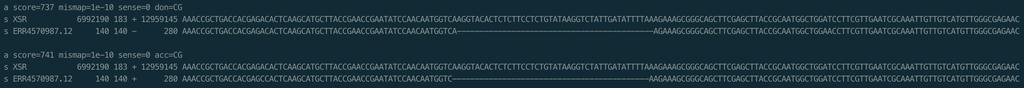

LAST-SPLIT may report introns as large deletions. Giving intron distribution info as options to LAST-SPLIT may change the results.

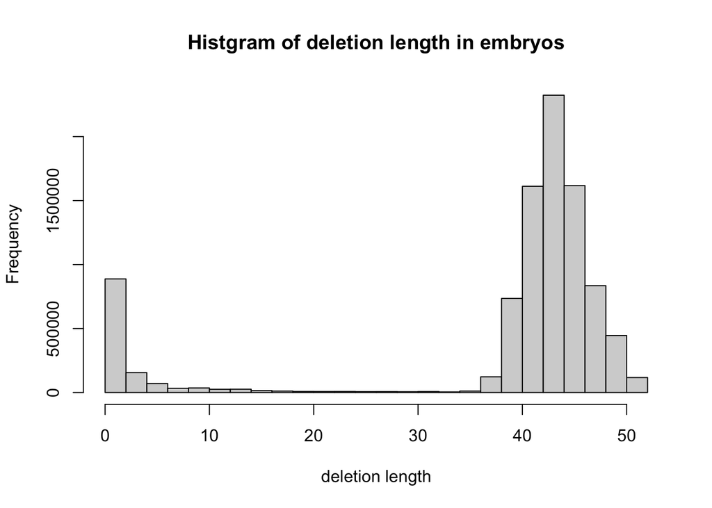

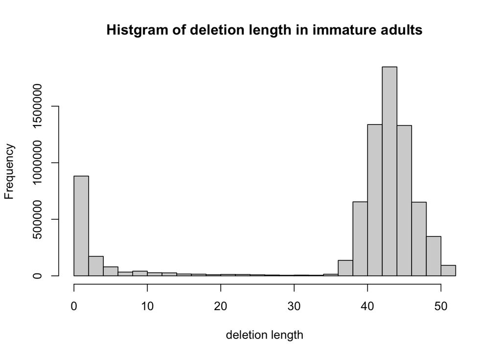

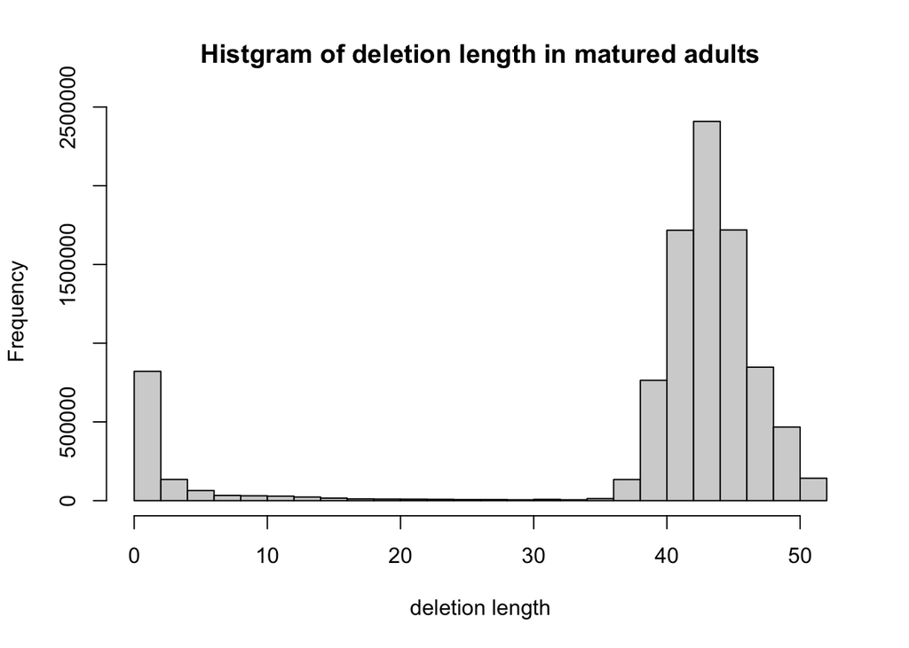

## Splicing Signals

I read output .MAF files of LAST-SPLIT, looked ‘don’ and ‘acc’ fields, and extracted donor-and-acceptor pairs.

I discarded data whose donor-and-acceptor pairs are unknown. (When both ends of the read are unaligned, it’s impossible to tell the donor-and-acceptor pairs from .MAF file).

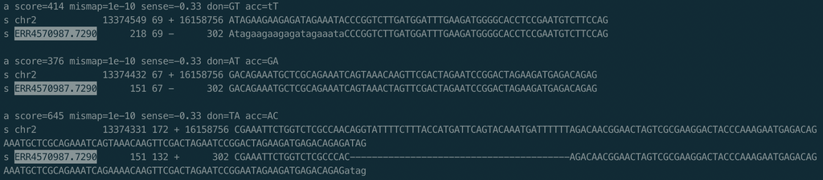

discarded data e.g.: matured adults, readID:ERR4570987.7290

The number of splicing signals detected are

- embryos: 3164
- immature adults: 3098
- matured adults: 3178

I arbitrary extracted splicing signals with >= 180,000 counts.

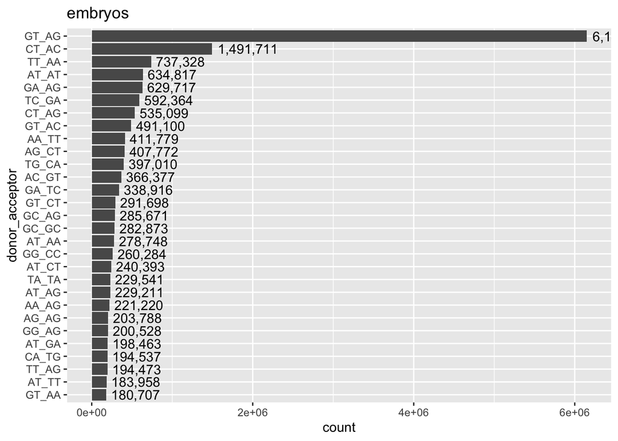

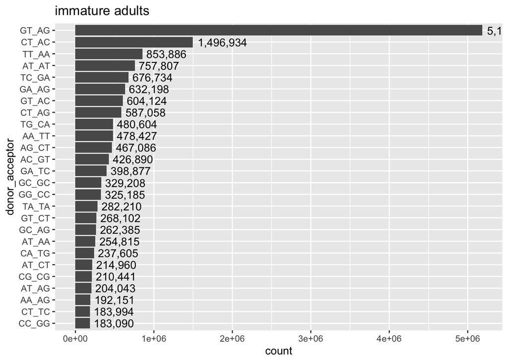

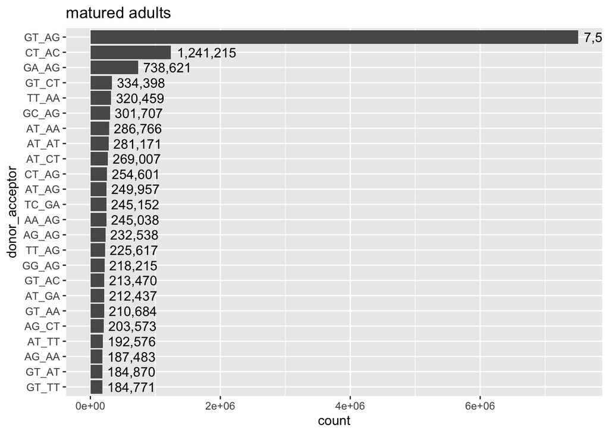

The number of GT_AG splicing signals

- embryos: 6146596
- immature adults: 5183373
- mature adults: 7505408

The percentage of non-canonical (non GT_AG, CT_AC) splicing signals

- embryos:73.3214383 %
- immature adults: 71.1372581 %
- matured adults: 68.6933841 %

There may be many canonical introns reported as large deletions. Pre-processing reads may also change the results.